# Homework Problems - Chapter 1

### Chapter 2 - Part 3 - Problem 2

The following is the logorithm for simulating a Markov chain with the **Uniform transition density**
$$p(x,y) = \tfrac{1}{2}\,1_{[x-1,\,x+1]}(y), \quad
x,y \in \mathbb{R}$$

$$\begin{array}{l}
\textbf{Algorithm: Simulating a Markov Chain with Uniform Transition
Density} \\[6pt]
1.\ \text{Set } X_0 = 0 \text{ (or draw from an initial distribution)}
\\[4pt]
2.\ \text{For } i = 1, 2, \ldots, n: \\[2pt]
\quad X_i \sim \text{Uniform}(X_{i-1} - 1,\; X_{i-1} + 1) \\[4pt]
3.\ \text{Return } (X_0, X_1, \ldots, X_n)
\end{array}$$

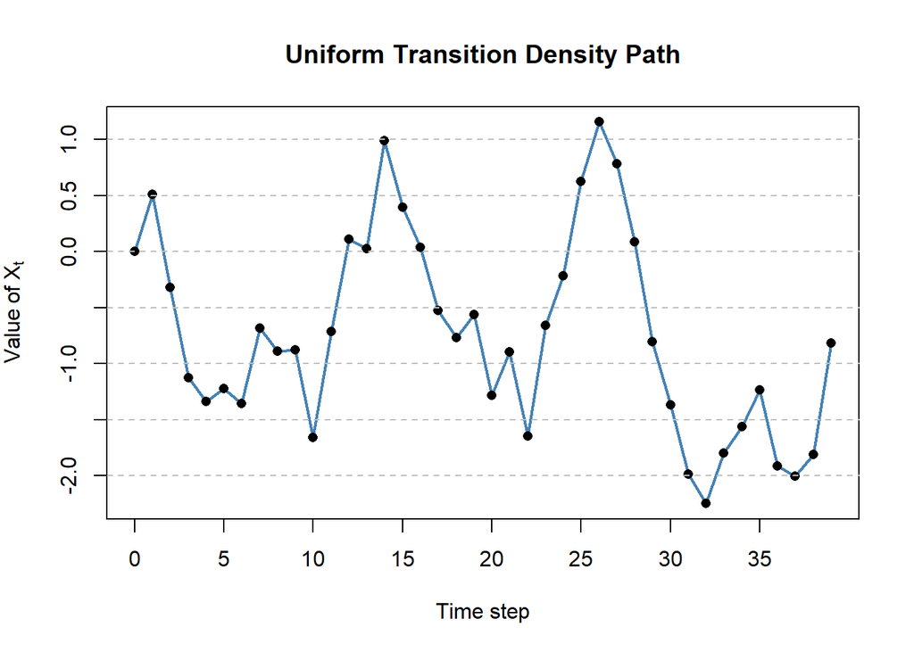

```r
T <- 40
x <- numeric(T)

for (t in 2:T) {
  x[t] <- runif(1, min = x[t - 1] - 1, max = x[t - 1] + 1)
}

plot(0:(T - 1), x,
     type = "l",lwd = 2, col = "steelblue",
     xlab = "Time step", ylab = expression(Value~of~X[t]),
     main = "Uniform Transition Density Path",
     xaxt = "n")
points(0:(T - 1), x, pch = 16, cex = 1)
axis(1, at = seq(0, T - 1, by = 5))
grid(nx = NA, ny = NULL, lty = "dashed", col = "gray")
```

### Chapter 2 - Part 4 - Problem 1

To simulate a Poisson process with **non-homogeneous intensity** $\lambda(x_1,x_2)$ over a rectangle:

1. Compute the **maximum intensity** $\lambda_{\max}$ over the rectangle.
2. Generate a **homogeneous Poisson process** with intensity $\lambda_{\max}$ over the rectangle.
3. For each point $(x_1, x_2)$, accept it with probability
   $$\frac{\lambda(x_1,x_2)}{\lambda_{\max}}$$
   (this is the **thinning step**).
4. The accepted points form a realization of the non-homogeneous Poisson process.

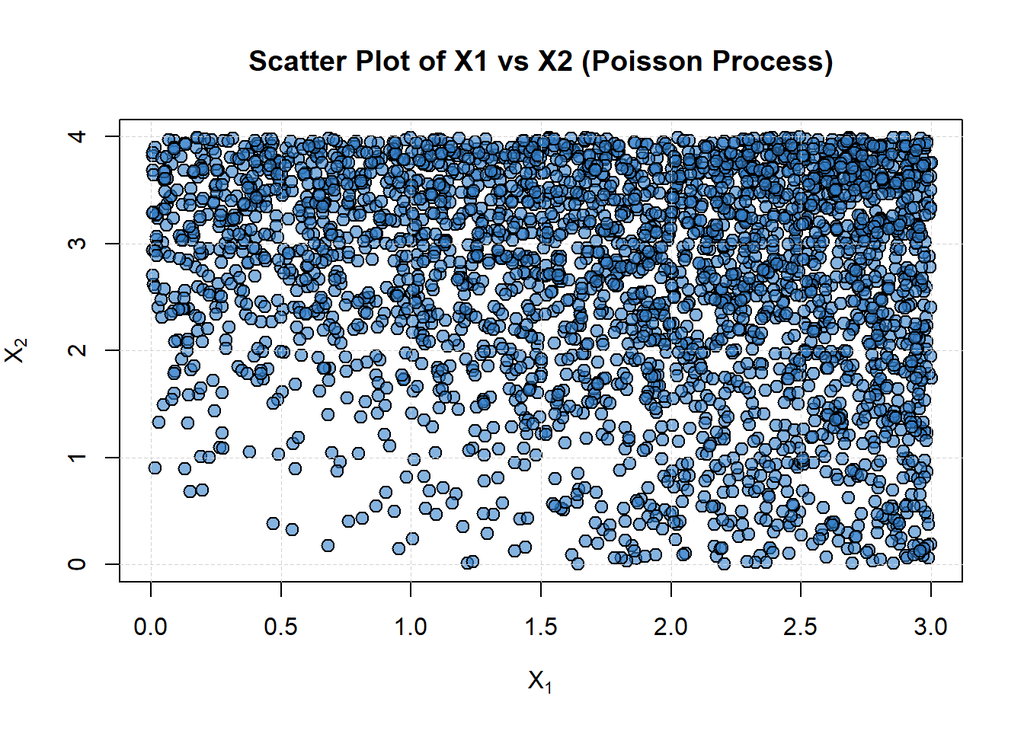

```r
# non-homogeneous intensity function
lambda_func <- function(x1, x2) {
  30 * (x1^2 + x2^2)
}

# rectangle boundaries
x1_min <- 0; x1_max <- 3
x2_min <- 0; x2_max <- 4

# maximum intensity for thinning
lambda_max <- lambda_func(x1_max, x2_max)

# step 1: number of candidate points (homogeneous Poisson)
area <- (x1_max - x1_min) * (x2_max - x2_min)
N <- rpois(1, lambda_max * area)

# step 2: candidate points uniformly on the rectangle
X1 <- runif(N, x1_min, x1_max)
X2 <- runif(N, x2_min, x2_max)

# step 3: thinning
U <- runif(N)
accepted <- U < lambda_func(X1, X2) / lambda_max
X1_thin <- X1[accepted]
X2_thin <- X2[accepted]

# step 4: plot
plot(X1_thin, X2_thin, pch = 21,
     bg = rgb(0.2, 0.5, 0.8, 0.6), col = "black", cex = 1.2,
     xlab = expression(X[1]), ylab = expression(X[2]),
     main = "Scatter Plot of X1 vs X2 (Poisson Process)",
     xlim = c(x1_min, x1_max), ylim = c(x2_min, x2_max),
     xaxt = "n", yaxt = "n")
axis(1,at = seq(0, x1_max, by = 0.5))
axis(2, at = seq(0, x2_max, by = 1))
grid(lty = "dashed", col = "lightgrey", lwd = 0.5)
```